# Bookbuyer Behavior Breakdown

## Analyzing trends of bestselling books on different platforms

Gesna Aggarwal, Brendan DeMilt, Lydia Hu

[figure not shown]

Picture taken from Twin Cities

# Part 0: Introduction

The Association of American Publishers reported that the book industry generated roughly $26.23 billion in revenue through 2.72 billion units in 2017. The Bureau of Labor Statistics estimates that there are just under 146,000 writers and authors working in the United States. Though readers of popular (as opposed to academic) books only reflect part of a population, and while books have shifted to [offering more formats](https://www.nytimes.com/2018/10/29/business/mini-books-pocket-john-green.html), using [different mediums](https://www.theguardian.com/books/2014/jul/14/david-mitchell-publishes-short-story-twitter), and being [marketed in more novel ways](https://www.theguardian.com/lifeandstyle/2019/sep/26/bookstagram-books-instagram-influencers-reading), the craft of the written word remains critical to culture and communication of society.

What, then, does the current landscape of popular books tell us about what is important to us as a culture today?

In America, one of the most well known (in industry and for consumers) bookseller metrics is the New York Times (NYT) bestseller list, based on unit sales of both print and e-books. See more detailed metholody [here](https://www.nytimes.com/books/best-sellers/methodology/). This project aims to glean insights from NYT bestselling books list from the year 2018. Some of the questions we are looking to answer include:

- How does genre of a published book relate to its bestseller potential?
- Does the length of a book impact whether or not it is likely to be a bestseller?
- What do these book characteristics tell us about what is appealing to readers?

### Contents:

- 1. Data Gathering
- 2. Data Cleaning and Management
- 3. Data Analysis
- 4. Hypothesis Testing and ML
- 5. Discussion
- 6. Conclusion

# Part 1: Data Gathering

We will be using the New York Times API to get the bestseller data and the OpenLibrary API to get additional information on each book.

## New York Times API - Data Extraction and Compilation

Our team used the New York Times Book API. This API provides information about book reviews and The New York Times Best Sellers lists.

According to the New York Time's [website](https://www.nytimes.com/books/best-sellers/methodology/),

> "The (bestseller) rankings reflect unit sales reported on a confidential basis by vendors offering a wide range of general interest titles published in the United States. Every week, thousands of diverse selling locations report their actual sales on hundreds of thousands of individual titles. The panel of reporting retailers is comprehensive and reflects sales in tens of thousands of stores of all sizes and demographics across the United States."

In order to get the bestseller data, there were several steps in the process

1. Our team had to register an account with the New York Times to get a key to access the data.
2. We created a function that returned a list of all the dates in 2018 in "YYYY-MM-DD" format. This is the format the Book API takes in date data.
3. The New York Times has bestsellers in 61 different categories. In order to narrow down the data that we analyze, we chose the two most general categories from this list. Namely - *Combined print and e-book fiction* and *Combined print and e-book non-fiction*
4. API calls were made for each day of 2018 for these two categories. All the data returned by the New York Times API is in the JSON format. This data was converted into a pandas dataframe and concatenated into one unified dataframe.
5. According to the guidelines for using the New York Times API, you can only make one API call every 6 seconds. Thus, creating this dataframe took a total of 73 minutes.
6. Once the dataframe was created, we were able to store it in the form of a CSV file. This CSV file is what we will be using for the rest of the analysis.

```python
import requests
import pandas as pd
import matplotlib.pyplot as plt
import time
import numpy as np
from sklearn.linear_model import LogisticRegression
from sklearn.ensemble import RandomForestClassifier
from sklearn.model_selection import train_test_split
```

```python
nyt_key = "QKADCGTZwzGLGNw0ANu79NoNHAvAE5m3"

#returns a list of all dates in 2018 in the YYYY-MM-DD format to pass into the New York Times API
def get2018Dates():
  allDates = []
  for i in range(1, 13):
    if i == 1 or i == 3 or i == 5 or i == 7 or i == 8 or i == 10 or i == 12:
      for j in range(1, 32):
        allDates.append("2018-" + str('%02d' % i) + "-" + str ('%02d' % j))
    if i == 2:
      for j in range(1, 29):
        allDates.append("2018-" + str('%02d' % i) + "-" + str ('%02d' % j))
    if i == 4 or i == 6 or i == 9 or i == 11:
      for j in range(1, 31):
        allDates.append("2018-" + str('%02d' % i) + "-" + str ('%02d' % j))
  return allDates

#get the type of books featured in the bestseller category for New York Times
getTypesOfBooks = requests.get('https://api.nytimes.com/svc/books/v3/lists/names.json?api-key='+nyt_key)
nyt_data = pd.DataFrame.from_dict(getTypesOfBooks.json()['results'])
typesOfBooks = []
typesOfBooks.append(nyt_data.list_name_encoded.unique()[0])
typesOfBooks.append(nyt_data.list_name_encoded.unique()[1])

#get all data for all books in 2018 and compile it into one dataset
all2018Dates = get2018Dates()
finalDataFrame = pd.DataFrame()

for date in all2018Dates:
  for bookType in typesOfBooks:
    apiCall = requests.get('https://api.nytimes.com/svc/books/v3/lists/' +
                           bookType + '/' + date + '.json?api-key=' + nyt_key)
    time.sleep(6)
    if 'results' in apiCall.json():
      test3 = apiCall.json()['results']
      dataFrame = pd.DataFrame(test3['books'])
      dataFrame['date'] = date
      dataFrame['typeOfBook'] = bookType
      finalDataFrame = pd.concat([dataFrame, finalDataFrame])
finalDataFrame.to_csv('data2.csv')
```

## OpenLibrary API

Since the NYT dataset doesn't contain more comprehensive data that would allow us to analyze the books holistically, we need to another data source to complete the details on these books. One such resource we utilize here is Open Library, which (as the name would suggest) is an open source library that catalogs the world's books. To start, we wrote a few helper methods using the Open Library API to help add standardized information to the data we already have on the bestselling books.

```python
OL_BASE = "https://openlibrary.org/api/books"

# returns information about a book if it exists, given the ISBN
def fetch_book(isbn):
    test = requests.get(OL_BASE+"?bibkeys=ISBN:"+str(isbn)+"&jscmd=data&format=json")
    if test.status_code == 200:
        return test.json()["ISBN:"+str(isbn)]
    else:
        return None

# gets a group of books, given an array of ISBNs
# agnostic to ISBN-10 or ISBN-13
def fetch_batch(arr):
    query = ""
    for i in arr:
        query += "ISBN:"+str(i)+","
    query = query[0:-1]
    test = requests.get(OL_BASE+"?bibkeys="+str(query)+"&jscmd=data&format=json")
    if test.status_code == 200:
        resp = test.json()
        ret = [None]*len(arr)
        for i in range(len(arr)):
            try:
                ret[i] = resp["ISBN:"+str(arr[i])]
            except KeyError:
                continue
        return ret
    else:
        return None

def fetch_batch_subsection(arr, subtitle):
    book = fetch_batch(arr)
    ret = [None]*len(book)
    for i in range(len(book)):
        try:
            sections = book[i][subtitle]
            ret[i] = [j["name"] for j in sections]
        except:
            continue
    return ret

def fetch_batch_section(arr, title):
    books = fetch_batch(arr)
    ret = [None]*len(books)
    for i in range(len(books)):
        try:
            ret[i] = books[i][title]
        except:
            continue
    return ret

def get_genres(isbn_arr):
    return fetch_batch_subsection(isbn_arr,"subjects")

def get_titles(isbn_arr):
    return fetch_batch_section(isbn_arr, "title")

def get_publishers(isbn_arr):
    return fetch_batch_subsection(isbn_arr,"publishers")

def get_publisher_locations(isbn_arr):
    return fetch_batch_subsection(isbn_arr,"publish_places")

def get_page_counts(isbn_arr):
    return fetch_batch_section(isbn_arr, "number_of_pages")

def get_publish_date(isbn_arr):
    return fetch_batch_section(isbn_arr, "publish_date")
```

# Part 2: Data Cleaning and Management

## New York Times - Data Cleaning

As mentioned before, we uploaded our code in the form of a .csv file. The original New York Times dataframe had many columns we would not need in our analysis. So before grouping our data by ISBNs, we dropped many columns and kept the following nine:

1. `Rank_List` = A list of all the ranks the book has had on the bestseller list.
2. `Weeks_On_List` = Total number of weeks the book has been on the bestseller list.
3. `ISBN13` = The ISBN13 of the book
4. `Publisher` = The publisher of the book
5. `Title` = The title of the book
6. `Author` = The author of the book
7. `Contributor` = The contributor of the book
8. `Dates` = The dates the book was on the bestseller list
9. `Book_Type` = The type of book it is (combined-print-and-e-book-nonfiction or combined-print-and-e-book-fiction)

```python
data = pd.read_csv('data2.csv')

#dropping columns that we will not be using
data = data.drop(['asterisk', 'dagger', 'amazon_product_url', 'book_review_link', 'first_chapter_link', 'book_image',
                 'book_image_width', 'book_image_height', 'buy_links', 'book_uri', 'article_chapter_link', 'isbns',
                 'contributor_note', 'sunday_review_link', 'description', 'price', 'primary_isbn10', 'age_group'], axis=1)

#grouping by the ISBN-13
grouped = data.groupby('primary_isbn13')

#creating the final dataframe
finalDataFrame = pd.DataFrame(columns = ['Rank_List', 'Weeks_On_List', 'ISBN13',
                                         'Publisher', 'Title', 'Author',
                                         'Contributor', 'Dates', 'Book_Type'])
iter = 0
for idx, dataframe in grouped:
    #create a list of all the days and ranks for the particular book on the bestseller list
    dates = []
    ranks = []
    for rows in dataframe.iterrows():
        dates.append(rows[1]['date'])
        ranks.append(rows[1]['rank'])
    dates = np.unique(dates)
    ranks = np.unique(ranks)

    #add data to the finalDataFrame
    finalDataFrame.loc[iter] = [ranks, dataframe['weeks_on_list'].iloc[0],
                                dataframe['primary_isbn13'].iloc[0],
                                dataframe['publisher'].iloc[0],
                                dataframe['title'].iloc[0],
                                dataframe['author'].iloc[0],
                                dataframe['contributor'].iloc[0], dates,
                                dataframe['typeOfBook'].iloc[0]]
    iter = iter + 1
finalDataFrame["Weeks_On_List"] = finalDataFrame["Weeks_On_List"].astype('int64')
finalDataFrame.head(10)
```

|  | Rank_List | Weeks_On_List | ISBN13 | Publisher | Title | Author | Contributor | Dates | Book_Type |
| --- | --- | --- | --- | --- | --- | --- | --- | --- | --- |
| 0 | [1, 2, 3, 9, 11, 15] | 12 | 9780060899226 | Ecco | KITCHEN CONFIDENTIAL | Anthony Bourdain | by Anthony Bourdain | [2018-06-25, 2018-06-26, 2018-06-27, 2018-06-2... | combined-print-and-e-book-nonfiction |
| 1 | [6] | 1 | 9780061998065 | HarperCollins | MEDIUM RAW | Anthony Bourdain | by Anthony Bourdain | [2018-07-09, 2018-07-10, 2018-07-11, 2018-07-1... | combined-print-and-e-book-nonfiction |
| 2 | [3, 4, 5, 8, 11, 13, 14] | 8 | 9780062294449 | Harper | THE NEXT PERSON YOU MEET IN HEAVEN | Mitch Albom | by Mitch Albom | [2018-10-22, 2018-10-23, 2018-10-24, 2018-10-2... | combined-print-and-e-book-fiction |
| 3 | [7, 9, 11, 13, 15] | 73 | 9780062300546 | HarperCollins | HILLBILLY ELEGY | JD Vance | by J.D. Vance | [2018-01-08, 2018-01-09, 2018-01-10, 2018-01-1... | combined-print-and-e-book-nonfiction |
| 4 | [3, 6, 11, 12, 13, 14, 15] | 85 | 9780062300553 | HarperCollins | HILLBILLY ELEGY | JD Vance | by J.D. Vance | [2018-05-14, 2018-05-15, 2018-05-16, 2018-05-1... | combined-print-and-e-book-nonfiction |
| 5 | [13, 14, 15] | 21 | 9780062316097 | Harper | SAPIENS | Yuval Noah Harari | by Yuval Noah Harari | [2018-01-22, 2018-01-23, 2018-01-24, 2018-01-2... | combined-print-and-e-book-nonfiction |
| 6 | [1, 14] | 38 | 9780062316103 | Harper | SAPIENS | Yuval Noah Harari | by Yuval Noah Harari | [2018-03-19, 2018-03-20, 2018-03-21, 2018-03-2... | combined-print-and-e-book-nonfiction |
| 7 | [5, 6, 7, 8, 9, 10, 11, 12, 13, 15] | 52 | 9780062316110 | Harper | SAPIENS | Yuval Noah Harari | by Yuval Noah Harari | [2018-05-28, 2018-05-29, 2018-05-30, 2018-05-3... | combined-print-and-e-book-nonfiction |
| 8 | [1, 2, 4, 5, 7, 9, 12, 14, 15] | 15 | 9780062319784 | Harper | I'LL BE GONE IN THE DARK | Michelle McNamara | by Michelle McNamara | [2018-03-12, 2018-03-13, 2018-03-14, 2018-03-1... | combined-print-and-e-book-nonfiction |
| 9 | [2] | 9 | 9780062319807 | Harper | I'LL BE GONE IN THE DARK | Michelle McNamara | by Michelle McNamara | [2018-05-07, 2018-05-08, 2018-05-09, 2018-05-1... | combined-print-and-e-book-nonfiction |

## Appending New York Times Data

We will now add the same columns to the New York Times dataset that it doesn't already have. This way, when it comes time to compare the two, we have standard data to work with. The only difference with this process is that, instead of using isbn-10 to gather data, we will be calling OpenLibrary with the isbn-13 number, as fewer books have an isbn10 number in the New York Times dataset (see isbn discussion in Part 5). The Open Library API limits each call to have about 200 isbns each, so we're going to have to make 3 calls to get all the data for each column.

```python
nyt = finalDataFrame

def createHugeColumn(x, arr):
    split = len(arr)//3
    column = pd.Series(x(arr[:split]))
    column = column.append(pd.Series(x(arr[split:2*split])))
    column = column.append(pd.Series(x(arr[2*split:])))
    column.index = [i for i in range(len(column))]
    return column

isbn13_arr = list(nyt["ISBN13"])
nyt["genres"] = createHugeColumn(get_genres, isbn13_arr)
nyt["publisher_location"] = createHugeColumn(get_publisher_locations, isbn13_arr).map(lambda x: x[0] if x != None else None)
nyt["page_count"] = createHugeColumn(get_page_counts,isbn13_arr)
nyt["OL_title"] = createHugeColumn(get_titles,isbn13_arr)
nyt.head(5)
```

|  | Rank_List | Weeks_On_List | ISBN13 | Publisher | Title | Author | Contributor | Dates | Book_Type | genres | publisher_location | page_count | OL_title |
| --- | --- | --- | --- | --- | --- | --- | --- | --- | --- | --- | --- | --- | --- |
| 0 | [1, 2, 3, 9, 11, 15] | 12 | 9780060899226 | Ecco | KITCHEN CONFIDENTIAL | Anthony Bourdain | by Anthony Bourdain | [2018-06-25, 2018-06-26, 2018-06-27, 2018-06-2... | combined-print-and-e-book-nonfiction | [Cooks, Accessible book, In library, Cocineros... | New York | 312.0 | Kitchen confidential |
| 1 | [6] | 1 | 9780061998065 | HarperCollins | MEDIUM RAW | Anthony Bourdain | by Anthony Bourdain | [2018-07-09, 2018-07-10, 2018-07-11, 2018-07-1... | combined-print-and-e-book-nonfiction | [nyt:paperback_nonfiction=2011-04-30, Nonficti... | New York | NaN | Medium Raw |
| 2 | [3, 4, 5, 8, 11, 13, 14] | 8 | 9780062294449 | Harper | THE NEXT PERSON YOU MEET IN HEAVEN | Mitch Albom | by Mitch Albom | [2018-10-22, 2018-10-23, 2018-10-24, 2018-10-2... | combined-print-and-e-book-fiction | [Amusement rides, Heaven, Older men, Death, Fu... | None | 213.0 | The next person you meet in Heaven |
| 3 | [7, 9, 11, 13, 15] | 73 | 9780062300546 | HarperCollins | HILLBILLY ELEGY | JD Vance | by J.D. Vance | [2018-01-08, 2018-01-09, 2018-01-10, 2018-01-1... | combined-print-and-e-book-nonfiction | None | None | NaN | Hillbilly Elegy |
| 4 | [3, 6, 11, 12, 13, 14, 15] | 85 | 9780062300553 | HarperCollins | HILLBILLY ELEGY | JD Vance | by J.D. Vance | [2018-05-14, 2018-05-15, 2018-05-16, 2018-05-1... | combined-print-and-e-book-nonfiction | [Mountain people, Family, Social mobility, Wor... | None | 288.0 | Hillbilly Elegy |

In addition, we'd like to make the book type column something a little more friendly to work with in our analysis. Instead of the strings `combined-print-and-e-book-nonfiction` and `combined-print-and-e-book-fiction`, we will encode this column to be 1 if the book is fiction, and 0 if it is nonfiction. It will also be beneficial to have a column containing the max rank a book had during its time on the list, so we will add a column with the highest rank the book ever achieved.

```python
nyt["Book_Type"] = nyt["Book_Type"].map(lambda x: 1 if x == "combined-print-and-e-book-fiction" else 0)
#Highest rank goes with minimum number, so we take the minimum of the rank list
nyt["max_rank"] = nyt["Rank_List"].map(lambda x: min(x))
nyt.head(5)
```

|  | Rank_List | Weeks_On_List | ISBN13 | Publisher | Title | Author | Contributor | Dates | Book_Type | genres | publisher_location | page_count | OL_title | max_rank |
| --- | --- | --- | --- | --- | --- | --- | --- | --- | --- | --- | --- | --- | --- | --- |
| 0 | [1, 2, 3, 9, 11, 15] | 12 | 9780060899226 | Ecco | KITCHEN CONFIDENTIAL | Anthony Bourdain | by Anthony Bourdain | [2018-06-25, 2018-06-26, 2018-06-27, 2018-06-2... | 0 | [Cooks, Accessible book, In library, Cocineros... | New York | 312.0 | Kitchen confidential | 1 |
| 1 | [6] | 1 | 9780061998065 | HarperCollins | MEDIUM RAW | Anthony Bourdain | by Anthony Bourdain | [2018-07-09, 2018-07-10, 2018-07-11, 2018-07-1... | 0 | [nyt:paperback_nonfiction=2011-04-30, Nonficti... | New York | NaN | Medium Raw | 6 |
| 2 | [3, 4, 5, 8, 11, 13, 14] | 8 | 9780062294449 | Harper | THE NEXT PERSON YOU MEET IN HEAVEN | Mitch Albom | by Mitch Albom | [2018-10-22, 2018-10-23, 2018-10-24, 2018-10-2... | 1 | [Amusement rides, Heaven, Older men, Death, Fu... | None | 213.0 | The next person you meet in Heaven | 3 |
| 3 | [7, 9, 11, 13, 15] | 73 | 9780062300546 | HarperCollins | HILLBILLY ELEGY | JD Vance | by J.D. Vance | [2018-01-08, 2018-01-09, 2018-01-10, 2018-01-1... | 0 | None | None | NaN | Hillbilly Elegy | 7 |
| 4 | [3, 6, 11, 12, 13, 14, 15] | 85 | 9780062300553 | HarperCollins | HILLBILLY ELEGY | JD Vance | by J.D. Vance | [2018-05-14, 2018-05-15, 2018-05-16, 2018-05-1... | 0 | [Mountain people, Family, Social mobility, Wor... | None | 288.0 | Hillbilly Elegy | 3 |

# Part 3: Data Analysis

Now that we have our data gathered, we can start exploring patterns among the books

## Rank vs weeks on the list

Firstly, we would like to see if there is a noticeable parent between the highest rank a book reached during its time on the list and how many weeks it was on the bestsellers list, and we will differentiate between fiction and non-fiction. In order to make the chart more human readable (mitigating the effects of extremes), we will take the average number of weeks for each rank for each type of book.

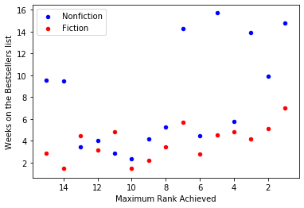

```python
fig, ax = plt.subplots()
#Since a lower rank number means higher rank, we invert the x axis
plt.gca().invert_xaxis()
for index, table in nyt.groupby("Book_Type"):
    color = 'b'
    if index == 1:
        color = 'r'
    avg = table.groupby("max_rank").mean().reset_index()
    avg.plot(kind="scatter", x="max_rank", y="Weeks_On_List", ax = ax, color = color);
ax.legend(["Nonfiction","Fiction"]);
ax.set_xlabel("Maximum Rank Achieved");
ax.set_ylabel("Weeks on the Bestsellers list");
```

From this chart, we can see there is a slight positive correlation between weeks spent on the list and max rank, with nonfiction books having a more drastic increase than fiction books. If we make a linear regression on these two sets of points we can the following result:

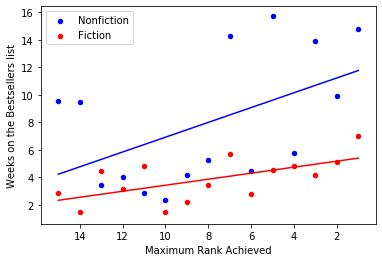

```python
for index, table in nyt.groupby("Book_Type"):
    color = 'b'
    if index == 1:
        color = 'r'
    avg = table.groupby("max_rank").mean().reset_index()
    func = np.poly1d(np.polyfit(avg["max_rank"], avg["Weeks_On_List"],1))
    ax.plot(avg["max_rank"],func(avg["max_rank"]), c=color)
ax.figure
```

We can easily see that linear regression more accurately encompasses the fiction correlation, but shows that nonficiton books typically spend more time overall on the bestsellers list. What is important to note is that both see a **positive correlation between high rank and number of weeks on the bestsellers list**. This might be explained by the fact that books at a high selling rank spend a longer time "Working its way down" the list in rank, until it is formally removed.

## Genre Analysis

Unfortunately, the OpenLibrary API proved to be less than effective, only covering about half of what's on the bestsellers list we generated, nonetheless, that's still over 250 data points to examine, so we will trim the dataset to those with identified genres and examine the makeup of them. We will first generate a map containing all of the occurences of each book genre

```python
nyt_g = nyt.dropna(subset=["genres"])
genre_map = {}

def add_genre(x):
    for i in x:
        try:
            genre_map[i] = genre_map[i]+1
        except KeyError:
            genre_map[i] = 1

nyt_g.apply(lambda x: add_genre(x["genres"]), axis=1)
genres = pd.DataFrame.from_dict(genre_map, orient="index").reset_index()
genres.columns =["Genre", "Count"]
genres = genres.sort_values(by="Count", ascending=False)
genres
```

|  | Genre | Count |
| --- | --- | --- |
| 24 | Fiction | 84 |
| 10 | Biography | 66 |
| 65 | Politics and government | 40 |
| 4 | History | 34 |
| 69 | Presidents | 22 |
| ... | ... | ... |
| 333 | Indians of North America | 1 |
| 334 | Powwows | 1 |
| 335 | FICTION / Political | 1 |
| 336 | Abandoned children | 1 |
| 744 | Republican Party (U.S. : 1854- ) | 1 |

745 rows × 2 columns

As we can see by the length of the DataFrame, Open Library maintains a very specific palette of genres to choose from.

```python
genres["Count"].describe()
```

```
count    745.000000
mean       1.852349
std        4.509214
min        1.000000
25%        1.000000
50%        1.000000
75%        2.000000
max       84.000000
Name: Count, dtype: float64
```

Based on these summary statistics on genre frequency, it's apparent that there are many niche genres that seemingly only appear for one book total, which provides little insight on the dataset as a whole, since a book can adopt multiple genres. For the sake of analysis, we will only keep genres with more than 5 occurrences in our dataset.

```python
genres = genres[genres["Count"] > 5]
genres
```

|  | Genre | Count |
| --- | --- | --- |
| 24 | Fiction | 84 |
| 10 | Biography | 66 |
| 65 | Politics and government | 40 |
| 4 | History | 34 |
| 69 | Presidents | 22 |
| 87 | United States | 17 |
| 118 | Murder | 13 |
| 119 | Investigation | 11 |
| 71 | Election | 8 |
| 67 | Political culture | 8 |
| 111 | Missing persons | 8 |
| 64 | Foreign relations | 8 |
| 32 | Social conditions | 7 |
| 29 | Case studies | 7 |
| 76 | Women | 7 |
| 163 | Man-woman relationships | 7 |
| 244 | Magic | 7 |
| 13 | Anecdotes | 7 |
| 26 | Family | 6 |

This specifies our data immensely. We can then plot the data in a bar plot

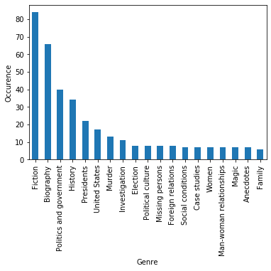

```python
bar = genres.plot(kind="bar", x ="Genre", legend=None)
bar.set_ylabel("Occurence");
```

Based on this plot, it is apparent that, outside of general fiction, **books that make the best seller list tend to be biographies and political books**, dominating the top 5 genres in the list. One could conclude that this is due to people wanting to read about people and topics potentially relevant to their own lives, and because politics can be both inflamatory and dramatic, or academic and informative.

## Page Count Analysis

One other thing we can examine is the average page length for a given genre. We can accomplish this with a simple modification for our frequency dictionary. We call an apply on the nyt_g dataframe and accumulate the total page number for each book in that genre

```python
genre_pages = {}

def genre_count(x):
    for i in x["genres"]:
        try:
            genre_pages[i] = genre_pages[i]+x["page_count"]
        except KeyError:
            genre_pages[i] = x["page_count"]

nyt_g.apply(lambda x: genre_count(x), axis=1)
genres_total = pd.DataFrame.from_dict(genre_pages, orient="index").reset_index()
genres_total.columns =["genre", "page_count"]
genres_total = genres_total.sort_values(by="page_count", ascending=False)
genres_total = genres_total.dropna()
genres_total
```

|  | genre | page_count |
| --- | --- | --- |
| 64 | Foreign relations | 3281.0 |
| 71 | Election | 2870.0 |
| 32 | Social conditions | 2496.0 |
| 357 | Intelligence officers | 2357.0 |
| 288 | Imaginary wars and battles | 2230.0 |
| ... | ... | ... |
| 448 | Civics & Citizenship | 126.0 |
| 444 | Twentieth century | 126.0 |
| 446 | Despotism | 126.0 |
| 441 | Modern History | 126.0 |
| 445 | Political ethics | 126.0 |

563 rows × 2 columns

Note the reduced amount of "raw" genres compared to when we were only computing frequency. This is because OpenLibrary does not always have the page count for a book, even if it does have genre data.

If we examine some statistical data we see

```python
genres_total.describe()
```

|  | page_count |
| --- | --- |
| count | 563.000000 |
| mean | 512.786856 |
| std | 385.952730 |
| min | 126.000000 |
| 25% | 300.500000 |
| 50% | 368.000000 |
| 75% | 578.000000 |
| max | 3281.000000 |

The page count data, like the mere frequency data, is heavily skewed, we can further examine this skew through a histogram

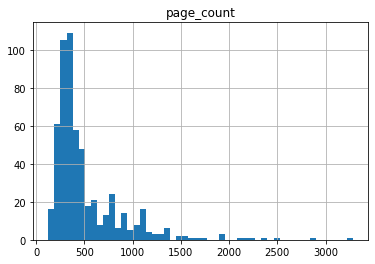

```python
genres_total.hist(bins=50);
```

To see which genres are responsible for the highest page counts, we take a similar approach as before:

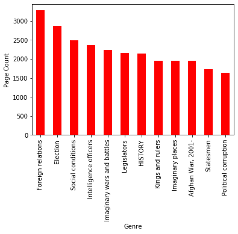

```python
pc = genres_total[:12].plot(kind="bar",x="genre", legend=None, color='r');
pc.set_ylabel("Page Count");
pc.set_xlabel("Genre");
```

To little surprise New York Times bestselling **books on politics, international studies**, and **history contribute the highest page counts**.

# Part 4: Hypothesis Testing and ML

## The Prediction of Fiction!

Can we use logistic regression classification to see if a book, based on the number of weeks on the bestsellers list, the highest rank it achieved, and the number of ranks it held, is fiction or not? We will use the sklearn library to build a logistic regression model as well as to create testing and training data, and eventually measure the accuracy of the model. In addition to the previous inputs, we also want to track which publisher the book is under, so we track that by creating an array with an index for every publisher in the dataset, and set the corresponding publisher index for a given book to 1, and concatenate that with the other variables.

```python
#Forming the column data into a matrix

publishers = list(nyt.groupby("Publisher").groups.keys())
def publisher_array(x):
    ret = [0]*len(publishers)
    ret[publishers.index(x)] = 1
    return ret

x = list(nyt.apply(lambda x: [len(x["Rank_List"]),x["max_rank"],x["Weeks_On_List"]]+publisher_array(x["Publisher"]),\
                   axis=1))
y = nyt["Book_Type"]
lr = LogisticRegression(solver='lbfgs',max_iter=300)
#Retrieving x and y test data on a 80/20 split
x_train, x_test, y_train, y_test = train_test_split(x, y, test_size=0.2)
lr.fit(x_train,y_train)
print("Model accuracy of "+str(lr.score(x_test,y_test)*100))
```

```
Model accuracy of 75.45454545454545
```

So, based on the results of this model, it can predict unseen data correctly with between 75-80% accuracy.

## Genre prediction

If you were an aspiring New York Times Best Seller, wouldn't you want to know what genre of book to write to get your book on the charts? Well given the data we have, we can use a random forest classifier to find out the exact genre to get you where you need to be!

Since our genre data comes in the form of an array, we want to extract the most 'popular' (frequently occurring) genre in that list and append a column to each row containing that specific genre. Luckily, we already have a dictionary containing that very information! All we do is select the genre with the highest frequency for each row

```python
def extract_max(x):
    max_genre = x[0]
    for i in x:
        if genre_map[i] > genre_map[max_genre]:
            max_genre = i
    return max_genre

nyt_g = nyt_g.copy()
nyt_g["max_genre"] = nyt_g["genres"].map(extract_max)
nyt_g.head(5)
```

|  | Rank_List | Weeks_On_List | ISBN13 | Publisher | Title | Author | Contributor | Dates | Book_Type | genres | publisher_location | page_count | OL_title | max_rank | max_genre |
| --- | --- | --- | --- | --- | --- | --- | --- | --- | --- | --- | --- | --- | --- | --- | --- |
| 0 | [1, 2, 3, 9, 11, 15] | 12 | 9780060899226 | Ecco | KITCHEN CONFIDENTIAL | Anthony Bourdain | by Anthony Bourdain | [2018-06-25, 2018-06-26, 2018-06-27, 2018-06-2... | 0 | [Cooks, Accessible book, In library, Cocineros... | New York | 312.0 | Kitchen confidential | 1 | Biography |
| 1 | [6] | 1 | 9780061998065 | HarperCollins | MEDIUM RAW | Anthony Bourdain | by Anthony Bourdain | [2018-07-09, 2018-07-10, 2018-07-11, 2018-07-1... | 0 | [nyt:paperback_nonfiction=2011-04-30, Nonficti... | New York | NaN | Medium Raw | 6 | Biography |
| 2 | [3, 4, 5, 8, 11, 13, 14] | 8 | 9780062294449 | Harper | THE NEXT PERSON YOU MEET IN HEAVEN | Mitch Albom | by Mitch Albom | [2018-10-22, 2018-10-23, 2018-10-24, 2018-10-2... | 1 | [Amusement rides, Heaven, Older men, Death, Fu... | None | 213.0 | The next person you meet in Heaven | 3 | Fiction |
| 4 | [3, 6, 11, 12, 13, 14, 15] | 85 | 9780062300553 | HarperCollins | HILLBILLY ELEGY | JD Vance | by J.D. Vance | [2018-05-14, 2018-05-15, 2018-05-16, 2018-05-1... | 0 | [Mountain people, Family, Social mobility, Wor... | None | 288.0 | Hillbilly Elegy | 3 | Biography |
| 8 | [1, 2, 4, 5, 7, 9, 12, 14, 15] | 15 | 9780062319784 | Harper | I'LL BE GONE IN THE DARK | Michelle McNamara | by Michelle McNamara | [2018-03-12, 2018-03-13, 2018-03-14, 2018-03-1... | 0 | [Serial murders, Case studies, Serial murder i... | USA | 352.0 | I'll Be Gone in the Dark | 1 | Case studies |

Now that we have a singular output designated for each book, we can now form a model to (attempt) to classify the kind of book it is.

For the input, we want the publisher to be taken into account in the decision trees that are generated. Now, since this is a set of decision trees, it does not really matter if we use ordinal variables to differentiate between publishers, so we can set each publisher to a unique numeric value.

```python
publishers = list(nyt_g.groupby("Publisher").groups.keys())
index = 0
publisher_value = {i: publishers.index(i) for i in publishers}
```

Now that a unique id has been set for every publisher, we can include it in our training data

For this random forest, we will use a forest of 100 trees, with the number of weeks on list, highest rank, book type, and publisher will all be inputs, and the most popular genre will be the output

```python
nyt_g = nyt_g.copy()
rf = RandomForestClassifier(n_estimators=100)
gx = list(nyt_g.apply(lambda x: [x["Weeks_On_List"], x["max_rank"], x["Book_Type"], \
                                 publisher_value[x["Publisher"]]],axis=1))
gy = nyt_g["max_genre"]
x_train, x_test, y_train, y_test = train_test_split(gx, gy, test_size=0.2)
rf.fit(x_train,y_train)
rf.score(x_test,y_test)*100
```

```
49.01960784313725
```

Well that accuracy isn't meaningless, but no better than a coin toss. Could results improve if, similar to our previous analysis, we only include more commonly assigned genres?

```python
nyt_pop_g = nyt_g.apply(lambda x: None if genre_map[x["max_genre"]] <= 5 else x, axis=1).dropna(how="all")
nyt_pop_g.head(5)
```

|  | Rank_List | Weeks_On_List | ISBN13 | Publisher | Title | Author | Contributor | Dates | Book_Type | genres | publisher_location | page_count | OL_title | max_rank | max_genre |
| --- | --- | --- | --- | --- | --- | --- | --- | --- | --- | --- | --- | --- | --- | --- | --- |
| 0 | [1, 2, 3, 9, 11, 15] | 12.0 | 9780060899226 | Ecco | KITCHEN CONFIDENTIAL | Anthony Bourdain | by Anthony Bourdain | [2018-06-25, 2018-06-26, 2018-06-27, 2018-06-2... | 0.0 | [Cooks, Accessible book, In library, Cocineros... | New York | 312.0 | Kitchen confidential | 1.0 | Biography |
| 1 | [6] | 1.0 | 9780061998065 | HarperCollins | MEDIUM RAW | Anthony Bourdain | by Anthony Bourdain | [2018-07-09, 2018-07-10, 2018-07-11, 2018-07-1... | 0.0 | [nyt:paperback_nonfiction=2011-04-30, Nonficti... | New York | NaN | Medium Raw | 6.0 | Biography |
| 2 | [3, 4, 5, 8, 11, 13, 14] | 8.0 | 9780062294449 | Harper | THE NEXT PERSON YOU MEET IN HEAVEN | Mitch Albom | by Mitch Albom | [2018-10-22, 2018-10-23, 2018-10-24, 2018-10-2... | 1.0 | [Amusement rides, Heaven, Older men, Death, Fu... | None | 213.0 | The next person you meet in Heaven | 3.0 | Fiction |
| 4 | [3, 6, 11, 12, 13, 14, 15] | 85.0 | 9780062300553 | HarperCollins | HILLBILLY ELEGY | JD Vance | by J.D. Vance | [2018-05-14, 2018-05-15, 2018-05-16, 2018-05-1... | 0.0 | [Mountain people, Family, Social mobility, Wor... | None | 288.0 | Hillbilly Elegy | 3.0 | Biography |
| 8 | [1, 2, 4, 5, 7, 9, 12, 14, 15] | 15.0 | 9780062319784 | Harper | I'LL BE GONE IN THE DARK | Michelle McNamara | by Michelle McNamara | [2018-03-12, 2018-03-13, 2018-03-14, 2018-03-1... | 0.0 | [Serial murders, Case studies, Serial murder i... | USA | 352.0 | I'll Be Gone in the Dark | 1.0 | Case studies |

Now that we narrowed our options to things a little more consistent, we can repeat the above steps and rebuild our random forest

```python
rfpop = RandomForestClassifier(n_estimators=100)
gx1 = list(nyt_pop_g.apply(lambda x: [x["Weeks_On_List"], x["max_rank"], x["Book_Type"], \
                                 publisher_value[x["Publisher"]]],axis=1))
gy1 = nyt_pop_g["max_genre"]
x_train, x_test, y_train, y_test = train_test_split(gx1, gy1, test_size=0.2)
rfpop.fit(x_train,y_train)
rfpop.score(x_test,y_test)*100
```

```
65.11627906976744
```

By eliminating niche genres, we were able to bump our accuracy reading by >10%! Not bad!

# Part 5: Discussion

### Complications and Shortcomings

One of the data complications that we considered involved the discrepancies between ISBN-10 and ISBN-13 values. ISBN stands for International Standard Book Number, which are purchased by publishers from an international agency that makes sure ISBNs are unique. The 10 digit and 13 digit ISBNs serve the same purpose, but the agency decided in 2007 to switch from 10 digit as the standard to 13 digits. Because the New York Times database has newer books, there are fewer books that use an isbn10 number in that dataset. While there is an algorithm that converts older ISBN-10s to ISBN-13s, the publishing sources we researched accept both. Therefore, for this project, our helper function uses both ISBN-13 and ISBN-10.

We scoped out this project to study only the data from one year’s worth of NYT bestseller data. As such, our dataset was capped to 550 entries. If the scope of this project were broadened and we wanted to expand our analysis, this analysis could be spread out to a longer amount of time, e.g., 3-5 years.

While the New York Times is one of the most highly regarded sources of book popularity, there is no one source that is the end all be all of what book merit or impact. For instance, the list does not take into account what books are being talked about the most on social media or which ones have the most reader generated content (e.g., reviews or fan art). Another source that originally considered using and delved into the API was **Goodreads**, a social reading site owned by Amazon that allows readers to follow each other, share reviews, create lists, groups, and communities. However, after cross referencing our information with Goodreads, we found that the data available through their API did not add value within the scope of our project.

### Further Reading

To learn more about the ins and outs of a bestsller:

- [HuffPost: The Writer's Odds of Success](https://www.huffpost.com/entry/the-writers-odds-of-succe_b_2806611)
- [Pacific Standard: What Makes A Book A Bestseller?](https://psmag.com/economics/what-makes-a-book-a-best-seller)
- [Northeastern: Science of a NYT Bestseller](https://news.northeastern.edu/2018/04/06/the-science-of-a-new-york-times-bestseller/)
- [Vox: Bestseller Lists Explained](https://www.vox.com/culture/2017/9/13/16257084/bestseller-lists-explained)
- [Literary Hub: Hacking the NYT List](https://lithub.com/8-notable-attempts-to-hack-the-new-york-times-bestseller-list/)

To learn more about some of the data science techniques used in this tutorial:

- [Medium: Random Forest Classifiers](https://towardsdatascience.com/understanding-random-forest-58381e0602d2)
- [Synced Review: Random Forests and Machine Learning](https://syncedreview.com/2017/10/24/how-random-forest-algorithm-works-in-machine-learning/)
- [Python Pandemonium: Data Visualization](https://medium.com/python-pandemonium/data-visualization-in-python-scatter-plots-in-matplotlib-da90ac4c99f9)
- [Codementor: Data Cleaning with Pandas](https://www.codementor.io/@ilyaas97/data-cleaning-in-python-basics-using-pandas-yw18j94yg)
- [DataQuest: Descriptive Statistics](https://www.dataquest.io/blog/basic-statistics-with-python-descriptive-statistics/)

# Part 6: Conclusion

### Overview

According to [Publishers Weekly](https://www.publishersweekly.com/pw/by-topic/industry-news/publisher-news/article/81473-number-of-self-published-titles-jumped-40-in-2018.html) the total number of print and e-books that were self-published in 2018 was *1.68 million.* Of these 1.68 million books, only 15 get chosen as bestsellers each week. One would think that with such a large dataset, every bestseller would be vastly different from each other. However, through our analysis, we were able to see that there are some factors that play into whether your book becomes a bestseller or not. There are definite trends seen within the 2018 bestseller data such as -

- Bestsellers tend to be in the following three genres – fiction, biography, and politics
- Bestsellers in the politics, information studies, and history genres have the highest page counts.

Based on the trends we saw, we continued to see if we could predict whether a book was fiction or not based on its bestseller data. Once we saw that this classifier was able to get a >75% accuracy, we further looked to see if we could predict the genre of the book based on bestseller information for which we got >65% accuracy.

### Why should you care?

As the world becomes more and more built on the internet, print media is becoming obsolete in many ways, as the phrase “adapt or die” comes into play for print newspapers, magazines, books, and other media. Readers also have more and more options for what to read, what format to consume it in, and how much to spend on it. Understanding what factors play into readers’ willingness to actually spend money on a book, then, is paramount for any person in the publishing industry to understand if they want to know what kind of writing to invest in, develop, and release in order to be financially viable.

Another way that bestseller lists are influential is that they serve as a way for people to understand an aspect of the national consciousness through how people are spending their time and money on one type of media. Therefore, we can discuss questions like: What are people paying attention to? What stories and characters– real or fictional– are we talking about? By considering trends in what books masses of people are buying, we can get an understanding of a part of the cultural backdrop and what is important or interesting to a group of people at a certain time.

# Thank you for reading! :) 📚